# Bilirubin concentrations and Ascities levels in Primary Biliary Cirrhosis.

## 0.1 Preliminaries

```r
library(skimr)
library(rms)
library(simputation)
library(broom)
library(tidyverse)
```

# 1 Task 1: Data Source

This dataset was found in appendix D of Fleming and Harrington, Counting Processes and Survival Analysis, Wiley, 1991. I have taken it from http://lib.stat.cmu.edu/datasets/ The dataset contains the data from the Mayo Clinic trial in primary biliary cirrhosis (PBC) of the liver conducted between 1974 and 1984.

A total of 424 PBC patients, referred to Mayo Clinic during that ten-year interval, met eligibility criteria for the randomized placebo controlled trial of the drug D-penicillamine. The first 312 cases in the data set participated in the randomized trial and contain largely complete data. The additional 112 cases did not participate in the clinical trial, but consented to have basic measurements recorded and to be followed for survival. Six of those cases were lost to follow-up shortly after diagnosis, so the data here are on an additional 106 cases as well as the 312 randomized participants. Missing data items are denoted by `.’. Thus, since many of the values were missing for last 112 people, I chose the first 312 values for the project. A more extended discussion can be found in Dickson, et al., Hepatology 10:1-7 (1989) and in Markus, et al., N Eng J of Med 320:1709-13 (1989).

# 2 Task 2: Load and Tidy the Data

```r
pbc <- read.csv("C:\\Users\\mani\\Desktop\\Case Acad\\Spring 2018\\tidypbc1.csv", header=T, na.strings=c(".","NA"))
na.strings=c("",". ","NA") %>% tbl_df()

pbc <- pbc %>% rename(alk_phos = alk.phos)

map_df(pbc, function(x) sum(is.na(x)))
```

```
# A tibble: 1 x 19
     ID fu.days status  drug  chol   alb copper alk_phos  sgot triglyc
  <int>   <int>  <int> <int> <int> <int>  <int>    <int> <int>   <int>
1     0       0      0     0    28     0      2        0     0      30
# ... with 9 more variables: plat <int>, protime <int>, stage <int>,
#   sex <int>, Bili <int>, ascities <int>, hepatem <int>, spiders <int>,
#   edema <int>
```

```r
## As we can see, Cholesterol has 28 missing values, Copper has 2, platelets has 4, and triglycerides has 30.

set.seed(40009)
pbc1 <- pbc %>% select(chol, copper, drug, fu.days, ID, plat, sex, stage, status, triglyc, alb, alk_phos, Bili, protime, sgot, edema, spiders, hepatem, ascities)  %>% impute_rhd(chol  ~ 1) %>% impute_rhd(copper  ~ 1) %>% impute_rhd(plat  ~ 1) %>% impute_rhd(triglyc ~ 1)

pbc2 <- pbc1
pbc2 <- pbc2 %>% mutate(status = as.factor(ifelse(status < 2, "Censored", "Death")))
pbc2 <- pbc2 %>% rename(female = sex)
pbc2 <- pbc2 %>%  mutate(drug = ifelse(drug == 1, "D-penicillamine", "Placebo"))

pbc2 <- pbc2 %>% mutate(stage = as.factor(ifelse(stage == 1, "Early", ifelse(stage == 2, "Mid", ifelse(stage == 3, "Advanced", "Extreme")))))
pbc2 <- pbc2 %>% mutate(edema = as.factor(ifelse(edema < 0.5, "No Edema", "Edema")))
```

1. Step 1: Converted all the “.” to NA values in order for skim to work.
2. Step 2: Checked for the missing values, if any. Found that Cholesterol has 28 missing values, Copper has 2, platelets has 4, and triglycerides has 30.
3. Step 3: Performed simple imputation to add the missing values in the numeric variables. The reason I performed simple imputation was that the number of missing values isn’t very large in the variables.
4. Step 4: Converted Status to a binary variable. Renamed Sex as Female Converted Drug into a character variable. Converted Stage into a factor variable with multiple levels. Converted edema into a factor variable with two levels.

# 3 Task 3: Listing of My Tibble

```r
pbc2 %>% tbl_df()
```

```
# A tibble: 312 x 19
    chol copper drug      fu.days    ID  plat female stage  status triglyc
   <dbl>  <dbl> <chr>       <int> <int> <dbl>  <int> <fct>  <fct>    <dbl>
 1   261  156   D-penici~     400     1   190      1 Extre~ Death    172
 2   302   54.0 D-penici~    4500     2   221      1 Advan~ Censo~    88.0
 3   176  210   D-penici~    1012     3   151      0 Extre~ Death     55.0
 4   244   64.0 D-penici~    1925     4   183      1 Extre~ Death     92.0
 5   279  143   Placebo      1504     5   136      1 Advan~ Censo~    72.0
 6   248   50.0 Placebo      2503     6   296      1 Advan~ Death     63.0
 7   322   52.0 Placebo      1832     7   204      1 Advan~ Censo~   213
 8   280   52.0 Placebo      2466     8   373      1 Advan~ Death    189
 9   562   79.0 D-penici~    2400     9   251      1 Mid    Death     88.0
10   200  140   Placebo        51    10   302      1 Extre~ Death    143
# ... with 302 more rows, and 9 more variables: alb <dbl>, alk_phos <dbl>,
#   Bili <dbl>, protime <dbl>, sgot <dbl>, edema <fct>, spiders <int>,
#   hepatem <int>, ascities <int>
```

The tibble has 312 observations(rows) in 19 columns, that is, 19 variables.

# 4 Task 4: Code Book

| Variable | Type | Details |
| --- | --- | --- |
| `ID` | Integer | ID(case number) of the people |
| `fu.days` | Integer | number of days between registration and the earlier of death,transplantion, or study analysis time in July, 1986 |
| `female` | Integer | Here, 1 means female, and 0 male |
| `stage` | factor | The stage of PBC (has 4 levels) |
| `status` | factor | Only two levels- Censored or Death |
| `drug` | Character | Two categories: D-penicillamine or Placebo |
| `alb` | numeric | values in gm/dl, ranging from 1.96 to 4.64 gm/dl |
| `plat` | numeric | values in cubic ml/1000, ranging from 62 to 563 cubic ml. |
| `chol` | numeric | Values in mg/dl, ranging from 120 to 1775 mg/dl |
| `Copper` | numeric | Values in ug/day, ranging from 4 to 588 ug/day |
| `triglyc` | numeric | In mg/dl, ranging from 33 to 598 mg/dl |
| `alk_phos` | numeric | In U/l.Ranges from 289 to 13862 U/l. |
| `Bili` | numeric | In mg/dl. Ranges from 0.3 to 28 mg/dl |
| `protime` | numeric | In seconds. Ranges from 9 to 17.2 seconds |
| `sgot` | numeric | In U/ml. Ranges from 26.35 to 457.25 U/ml |
| `edema` | factor | Presence or absence of edema |
| `hepatem` | integer | Presence of hepatomegaly. Binary variable |
| `ascities` | integer | Presence of ascities. Binary variable |
| `spiders` | integer | Presence of spider angiomas. Binary variable. |

# 5 Task 5: My Subjects

This dataset is about the PBC(primary biliary cirrhosis) trial conducted in 312 patients from 1974-1984. One of the purposes of the study was to make survival models for patients with PBC, using Serum Bilirubin and albumin concentrations and prothrombin time. Further information is provided in the paper: Dickson, E. R., Grambsch, P. M., Fleming, T. R., Fisher, L. D. and Langworthy, A. (1989), Prognosis in primary biliary cirrhosis: Model for decision making. Hepatology, 10: 1-7. doi:10.1002/hep.1840100102

# 6 Task 6: My Variables

There are 19 variables (or columns) in the dataset:

1. ID: Specifes the case number of the patients. A total of 312 patients in this study.
2. fu.days: Number of days between registration and the earlier of death, transplantion, or study analysis time in July, 1986
3. female: Gender of the patients involved in the study.
4. stage: The stage at which the disease was at. It is a multicategorical variable with 4 different levels.
5. status: Status of the patients when the trial ended. Either dead or censored
6. drug: The drug patients were given. They were either given D-penicillamine, or placebo.
7. alb: The concentration of albumin present in the serum. Given in gm/dl.
8. plat: The concentration of platelets in the patients. It is given in cubic ml/1000
9. chol: The concentration of cholesterol in the patients. It is given in mg/dl.
10. copper: The concentration of copper removed through urine. It is given in ug/day.
11. triglyc: The concentration of triglycerides in the patients. Given in mg/dl.
12. alk_phos: The concentration of alkaline phosphatase, given in U/l
13. sgot: Serum glutamic oxaloacetic transaminase, an enzyme secreted by the liver. It’s concentration is provided in U/ml
14. protime: It is the time taken by prothrombin to form. It is provided in seconds.
15. Bili: Bilirubin concentrations in the serum. Given in mg/dl
16. ascities: It denotes the presence or absence of ascities, which is abnormal accumulation of fluids
17. hepatem: Hepatomegaly , is the abnormal enlargement of liver, and is given as wither present or absent.
18. spiders: spider angiomas, is a disease caused in the liver. It is a binary variable here.
19. edema: Also refers to accumulation of abnormal quantity of fluids, but in different areas. It is converted into a binary factor here.

# 7 Task 7: My Planned Linear Regression Model

Higher bilirubin levels are associated with occruance of PBC. I plan to see concentrations of other variables and how they affect the Bilirubin levels. Thus, I plan on having the variable “bilirubin” as the outcome variable. My predicting variables shall be: 1. Copper 2. SGOT 3. spiders 4. Alkaline Phosphatase 5. Stage 6. Drug

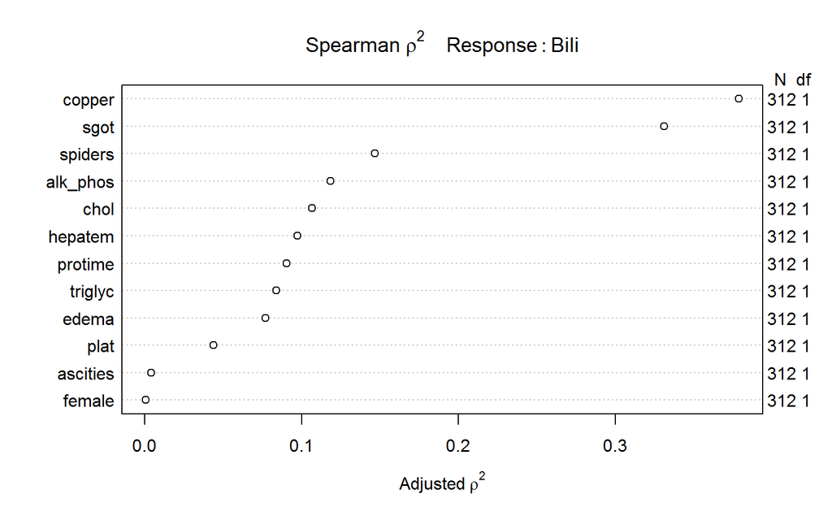

```r
spear.Bili <- spearman2(Bili ~ alk_phos + protime + triglyc + chol + female + copper + sgot + plat + ascities + hepatem + edema + spiders, data = pbc2)

plot(spear.Bili)
```

Here, Copper and SGOT are the two most important variables according to the spearman Rho square plot

# 8 Task 8: My Planned Logistic Regression Model

I plan on having “Ascities” as the binary outcome variable. My other predictors shall be: 1. hepatem 2. Protime 3. Female 4. Status 5. Stage 6. Copper 7. Alkaline Phosphatase.

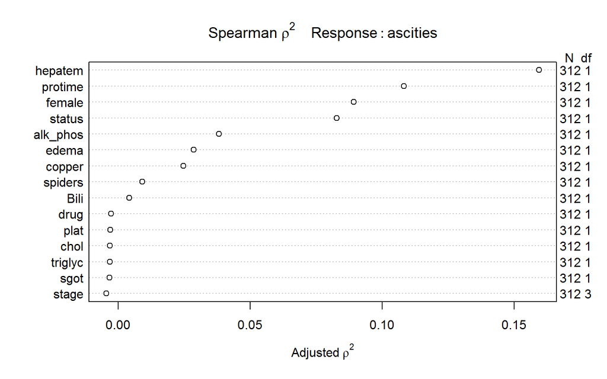

```r
spear.ascities <- spearman2(ascities ~ alk_phos + protime + triglyc + chol + female + copper + sgot + plat + stage + status + Bili + drug + spiders + edema + hepatem, data = pbc2)

plot(spear.ascities)
```

# 9 Task 9: Affirmation

The dataset fulfills all the necessary requirements of the project. It has more than 100 observations in 19 variables.

I am certain that it is completely appropriate for this data to be shared with anyone, without any conditions. There are no concerns about privacy or security.

# 10 Task 10: Linear Regression

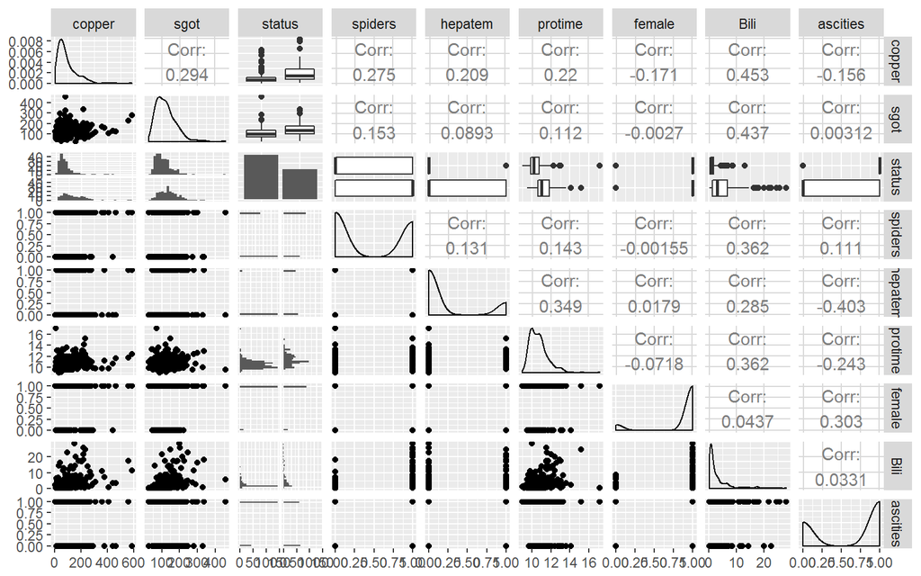

```r
temp <- pbc2 %>%
select(copper, sgot, status, spiders, hepatem, protime, female, Bili, ascities)
GGally::ggpairs(temp)
```

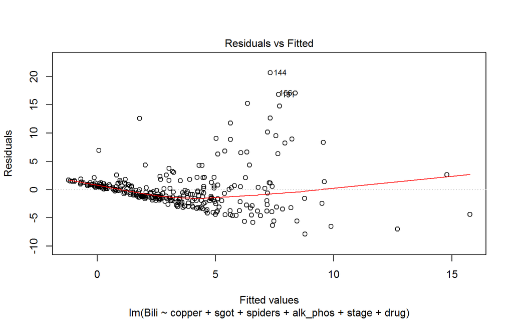

```r
# Checking if the linear model would be a good fit

plot(lm(Bili ~ copper + sgot + spiders + alk_phos + stage + drug, data = pbc2), which = 1)
```

```r
# Tried to fit in a quadratic model. Didn't work, as can be seen.
lm_1 <- lm(Bili ~ copper^2 + sgot + spiders + alk_phos + stage + drug, data = pbc2)
summary(lm_1)
```

```
Call:
lm(formula = Bili ~ copper^2 + sgot + spiders + alk_phos + stage +
    drug, data = pbc2)

Residuals:
    Min      1Q  Median      3Q     Max
-7.8894 -1.6964 -0.4604  0.8333 20.6761

Coefficients:
               Estimate Std. Error t value Pr(>|t|)
(Intercept)  -2.716e+00  6.452e-01  -4.210 3.37e-05 ***
copper        1.529e-02  2.715e-03   5.631 4.09e-08 ***
sgot          2.505e-02  3.889e-03   6.439 4.69e-10 ***
spiders       1.995e+00  4.719e-01   4.228 3.13e-05 ***
alk_phos      6.486e-05  9.953e-05   0.652    0.515
stageEarly    4.806e-01  1.006e+00   0.478    0.633
stageExtreme  4.026e-01  5.123e-01   0.786    0.433
stageMid      5.082e-02  5.654e-01   0.090    0.928
drugPlacebo   4.998e-01  4.212e-01   1.187    0.236
---
Signif. codes:  0 '***' 0.001 '**' 0.01 '*' 0.05 '.' 0.1 ' ' 1

Residual standard error: 3.668 on 303 degrees of freedom
Multiple R-squared:  0.3617,    Adjusted R-squared:  0.3448
F-statistic: 21.46 on 8 and 303 DF,  p-value: < 2.2e-16
```

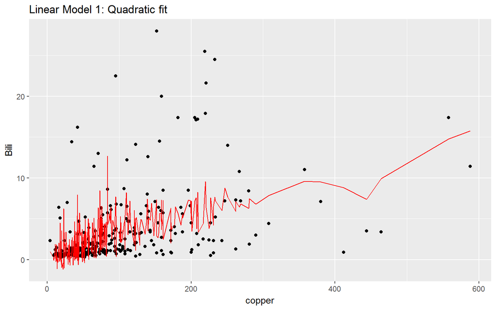

```r
lm_1.aug <- augment(lm_1, pbc2)
ggplot(lm_1.aug, aes(x = copper, y = Bili)) + geom_point() + geom_line(aes(x = copper, y = .fitted), col = "red") + labs(title = "Linear Model 1: Quadratic fit")
```

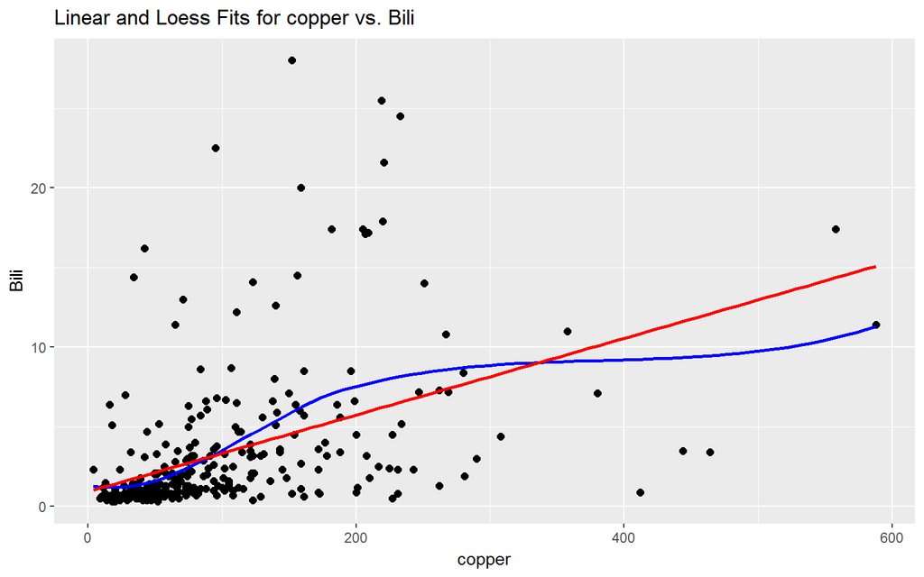

```r
ggplot(pbc2, aes(x = copper, y = Bili)) +
geom_point(size = 2) +
geom_smooth(method = "loess", se = FALSE, col = "blue") +
geom_smooth(method = "lm", se = FALSE, col = "red") +
labs(title = "Linear and Loess Fits for copper vs. Bili")
```

```r
# Checking whether copper would be a  good fit as a loess model

lm_2 <- lm(Bili ~ poly(copper,3) + sgot + spiders + alk_phos + stage + drug, data = pbc2)
summary(lm_2)
```

```
Call:
lm(formula = Bili ~ poly(copper, 3) + sgot + spiders + alk_phos +
    stage + drug, data = pbc2)

Residuals:
    Min      1Q  Median      3Q     Max
-7.3047 -1.8313 -0.4649  0.9625 20.3970

Coefficients:
                   Estimate Std. Error t value Pr(>|t|)
(Intercept)      -1.100e+00  6.864e-01  -1.603   0.1099
poly(copper, 3)1  2.358e+01  4.108e+00   5.740 2.30e-08 ***
poly(copper, 3)2 -8.053e+00  3.737e+00  -2.155   0.0319 *
poly(copper, 3)3 -1.268e+00  3.799e+00  -0.334   0.7388
sgot              2.477e-02  4.000e-03   6.192 1.94e-09 ***
spiders           1.923e+00  4.712e-01   4.081 5.75e-05 ***
alk_phos          3.633e-05  1.005e-04   0.362   0.7179
stageEarly        5.304e-01  1.001e+00   0.530   0.5967
stageExtreme      4.030e-01  5.108e-01   0.789   0.4307
stageMid          1.190e-01  5.641e-01   0.211   0.8330
drugPlacebo       4.602e-01  4.196e-01   1.097   0.2737
---
Signif. codes:  0 '***' 0.001 '**' 0.01 '*' 0.05 '.' 0.1 ' ' 1

Residual standard error: 3.651 on 301 degrees of freedom
Multiple R-squared:  0.3717,    Adjusted R-squared:  0.3509
F-statistic: 17.81 on 10 and 301 DF,  p-value: < 2.2e-16
```

I have not yet finalized which model to use yet. I’m still comparing them to figure out the best ones. I have to make more models to figure it out.

Satyakam Mishra

2018-03-08 10:51:31